# maiac_0612_thresholds

Helen MIller

June 12, 2018

```r
oct08Afull <- maiac_loadRaster("h01v04", 20171008, 2105, converterPath = "../executables/h4toncff_nc4")
oct08A <- projectRaster(oct08Afull, crs = CRS("+proj=longlat +ellps=GRS80 +datum=NAD83 +no_defs +towgs84=0,0,0")) %>%
  crop(raster::extent(-125.52, -117.03, 36.52, 41.78))
oct08T <- maiac_loadRaster("h01v04", 20171008, 1930, product = "MAIACTAOT", converterPath = "../executables/h4toncff_nc4") %>%
  projectRaster(crs = CRS("+proj=longlat +ellps=GRS80 +datum=NAD83 +no_defs +towgs84=0,0,0")) %>%
  crop(raster::extent(-125.52, -117.03, 36.52, 41.78))
oct09A <- maiac_loadRaster("h01v04", 20171009, 2150, converterPath = "../executables/h4toncff_nc4") %>%
  projectRaster(crs = CRS("+proj=longlat +ellps=GRS80 +datum=NAD83 +no_defs +towgs84=0,0,0")) %>%
  crop(raster::extent(-125.52, -117.03, 36.52, 41.78))
oct09Tpre <- maiac_loadRaster("h01v04", 20171009, product = "MAIACTAOT", converterPath = "../executables/h4toncff_nc4") %>%
  projectRaster(crs = CRS("+proj=longlat +ellps=GRS80 +datum=NAD83 +no_defs +towgs84=0,0,0"))
oct09T <- crop(oct09Tpre, raster::extent(-125.52, -117.03, 36.52, 41.78))
oct10A <- maiac_loadRaster("h01v04", 20171010, converterPath = "../executables/h4toncff_nc4") %>%
  projectRaster(crs = CRS("+proj=longlat +ellps=GRS80 +datum=NAD83 +no_defs +towgs84=0,0,0")) %>%
  crop(raster::extent(-125.52, -117.03, 36.52, 41.78))
oct10T <- maiac_loadRaster("h01v04", 20171010, 1915, product = "MAIACTAOT", converterPath = "../executables/h4toncff_nc4") %>%
  projectRaster(crs = CRS("+proj=longlat +ellps=GRS80 +datum=NAD83 +no_defs +towgs84=0,0,0")) %>%
  crop(raster::extent(-125.52, -117.03, 36.52, 41.78))
oct11A <- maiac_loadRaster("h01v04", 20171011, 2135, converterPath = "../executables/h4toncff_nc4") %>%
  projectRaster(crs = CRS("+proj=longlat +ellps=GRS80 +datum=NAD83 +no_defs +towgs84=0,0,0")) %>%
  crop(raster::extent(-125.52, -117.03, 36.52, 41.78))
oct11T <- maiac_loadRaster("h01v04", 20171011, 1820, product = "MAIACTAOT", converterPath = "../executables/h4toncff_nc4") %>%
  projectRaster(crs = CRS("+proj=longlat +ellps=GRS80 +datum=NAD83 +no_defs +towgs84=0,0,0")) %>%
  crop(raster::extent(-125.52, -117.03, 36.52, 41.78))
oct12A <- maiac_loadRaster("h01v04", 20171012, 2040, converterPath = "../executables/h4toncff_nc4") %>%
  projectRaster(crs = CRS("+proj=longlat +ellps=GRS80 +datum=NAD83 +no_defs +towgs84=0,0,0")) %>%
  crop(raster::extent(-125.52, -117.03, 36.52, 41.78))
oct12T <- maiac_loadRaster("h01v04", 20171012, product = "MAIACTAOT", converterPath = "../executables/h4toncff_nc4") %>%
  projectRaster(crs = CRS("+proj=longlat +ellps=GRS80 +datum=NAD83 +no_defs +towgs84=0,0,0")) %>%
  crop(raster::extent(-125.52, -117.03, 36.52, 41.78))
oct13A <- maiac_loadRaster("h01v04", 20171013, converterPath = "../executables/h4toncff_nc4") %>%
  projectRaster(crs = CRS("+proj=longlat +ellps=GRS80 +datum=NAD83 +no_defs +towgs84=0,0,0")) %>%
  crop(raster::extent(-125.52, -117.03, 36.52, 41.78))
oct13T <- maiac_loadRaster("h01v04", 20171013, 1945, product = "MAIACTAOT", converterPath = "../executables/h4toncff_nc4") %>%
  projectRaster(crs = CRS("+proj=longlat +ellps=GRS80 +datum=NAD83 +no_defs +towgs84=0,0,0")) %>%
  crop(raster::extent(-125.52, -117.03, 36.52, 41.78))
```

## Determining AQI thresholds for AOT

https://www.analyticsvidhya.com/blog/2015/11/beginners-guide-on-logistic-regression-in-r/

The best-fit logistic regression returns a slope and intercept for a linear equation which predicts the log-odds of the probability (*p*) of PM25 being over the threshold, based on the AOT value. I calculate AOT thresholds corresponding to AQI thresholds by solving for *p* = 0.5, that is, I find the AOT value at which the model predicts that the probability of PM25 being over the AQI threshold is 0.5. AQI and AOT thresholds are plotted below.

### Calculating AOT threshold from logistic model

R gives us $\beta_0$ and $\beta_1$ for the logistic equation of the form:
$$\log\left(\frac{p}{1-p}\right) = \beta_0 + \beta_1 x$$

where $p$ is the probability of the monitoring value exceeding the threshold, and *x* is AOT.

Solving for $p = .5$, we get:

$$x = -\frac{\beta_0}{\beta_1}$$
We can also calculate $p$ from $x$:

## Evaluating the models

https://www.r-bloggers.com/evaluating-logistic-regression-models/

Use McFadden’s R2 as a method of assessing model. It is defined as 1−[ln(LM)/ln(L0)] where log(LM) is the log-likelihood value for the fitted model, and lm(L0) is the log-likelihood value for the null model where the slope equals 0. It ranges from 0 to 1, with higher values indicating a better fit. The intercept can be interpreted as the predicted odds (1/(1-p)) of the PM25 value being over the threshold when AOT is 0, and the odds are predicted to increase by a factor of the slope value for one unit increase in AOT.

```r
dfall$moderate <- ifelse(dfall$monitor > 12, TRUE, FALSE)
dfall$usg <- ifelse(dfall$monitor > 35.5, TRUE, FALSE)
dfall$unhealthy <- ifelse(dfall$monitor > 55.5, TRUE, FALSE)
dfall$veryunhealthy <- ifelse(dfall$monitor > 150.5, TRUE, FALSE)
dfall$hazardous <- ifelse(dfall$monitor > 250.5, TRUE, FALSE)

moderateglm <- glm(moderate~satellite, data = dfall, family = binomial)
moderateThreshold <- -(moderateglm$coefficients[1]/moderateglm$coefficients[2])

usgglm <- glm(usg~satellite, data = dfall, family = binomial)
usgThreshold <- -(usgglm$coefficients[1]/usgglm$coefficients[2])

unhealthyglm <- glm(unhealthy~satellite, data = dfall, family = binomial)
unhealthyThreshold <- -(unhealthyglm$coefficients[1]/unhealthyglm$coefficients[2])

veryunhealthyglm <- glm(veryunhealthy ~ satellite, data = dfall, family = binomial)
veryunhealthyThreshold <- -(veryunhealthyglm$coefficients[1]/veryunhealthyglm$coefficients[2])

hazardousglm <- glm(hazardous ~ satellite , data = dfall, family = binomial)
hazardousThreshold <- -(hazardousglm$coefficients[1]/hazardousglm$coefficients[2])

thresholds <- c(moderateThreshold, usgThreshold, unhealthyThreshold, veryunhealthyThreshold, hazardousThreshold)


intercepts <- exp(c(moderateglm$coefficients[1], usgglm$coefficients[1], unhealthyglm$coefficients[1], veryunhealthyglm$coefficients[1], hazardousglm$coefficients[1]))
slopes <- exp(c(moderateglm$coefficients[2], usgglm$coefficients[2], unhealthyglm$coefficients[2], veryunhealthyglm$coefficients[2], hazardousglm$coefficients[2]))
mcfadden <- c(pscl::pR2(moderateglm)[4], pscl::pR2(usgglm)[4], pscl::pR2(unhealthyglm)[4], pscl::pR2(veryunhealthyglm)[4], pscl::pR2(hazardousglm)[4])

knitr::kable(data.frame(AQI = AQI$names[-1], pm25 = AQI$breaks_24[2:6], AOT_threshold = thresholds, intercept = intercepts, slope = slopes, McFadden_R2 = mcfadden))
```

| AQI | pm25 | AOT_threshold | intercept | slope | McFadden_R2 |
| --- | --- | --- | --- | --- | --- |
| Moderate | 12.0 | 0.1427335 | 0.1583684 | 4.047397e+05 | 0.4012459 |
| USG | 35.5 | 0.3599233 | 0.0176342 | 7.451978e+04 | 0.6228330 |
| Unhealthy | 55.5 | 0.4681644 | 0.0078300 | 3.154458e+04 | 0.6691613 |
| Very Unhealthy | 150.5 | 1.2858559 | 0.0032342 | 8.642390e+01 | 0.5572667 |
| Hazardous | 250.5 | 1.8150409 | 0.0000000 | 6.419847e+47 | 1.0000000 |

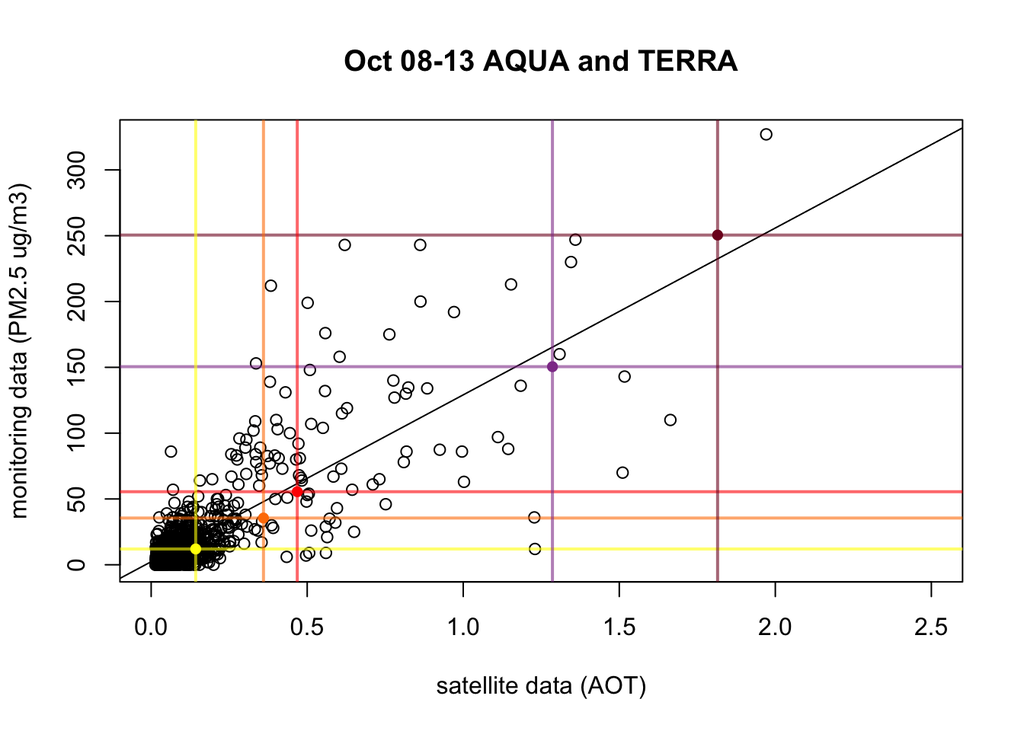

```r
plot(dfall$satellite, dfall$monitor, main = "Oct 08-13 AQUA and TERRA", ylab = "monitoring data (PM2.5 ug/m3)", xlab = "satellite data (AOT)", xlim = c(0,2.5), ylim = c(0,325))
abline(lm(dfall$monitor~dfall$satellite))
points(AQI$breaks_24[2:6]~ thresholds, col = AQI$colors[-1], pch = 16)
abline(h = AQI$breaks_24[-1], col = adjustcolor(AQI$colors[-1], alpha.f = .6), lwd = 2)
abline(v = thresholds, col = adjustcolor(AQI$colors[-1], alpha.f = .6), lwd = 2)
```

## Threshold Plots

These plots show how AOT is related to the AQI threshold. On the x axis, we have AOT. The y-axis is binary, with points on top at 1 or TRUE when the monitor PM25 value exceeded the threshold, or at 0 or FALSE when it did not. They also include a line showing the predicted probability that the monitor PM25 value will exceed the threshold given a value for AOT.

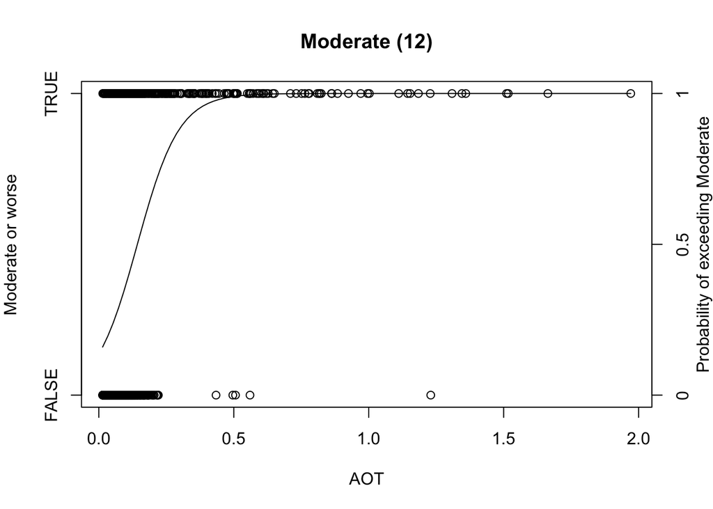

```r
par(mar = c(5,4,4,3))
plot(dfall$satellite, dfall$moderate, xlab = "AOT", ylab = "Moderate or worse", yaxt = 'n', main = "Moderate (12)")
axis(2, at = c(0, 1), labels = c("FALSE", "TRUE"))
axis(4, at = c(0, .5,  1), labels = c("0", "0.5", "1"))
mtext("Probability of exceeding Moderate", 4, 2)
curve(exp(moderateglm$coefficients[1] + moderateglm$coefficients[2] * x)/(1 + exp(moderateglm$coefficients[1] + moderateglm$coefficients[2] * x)), add = TRUE)
```

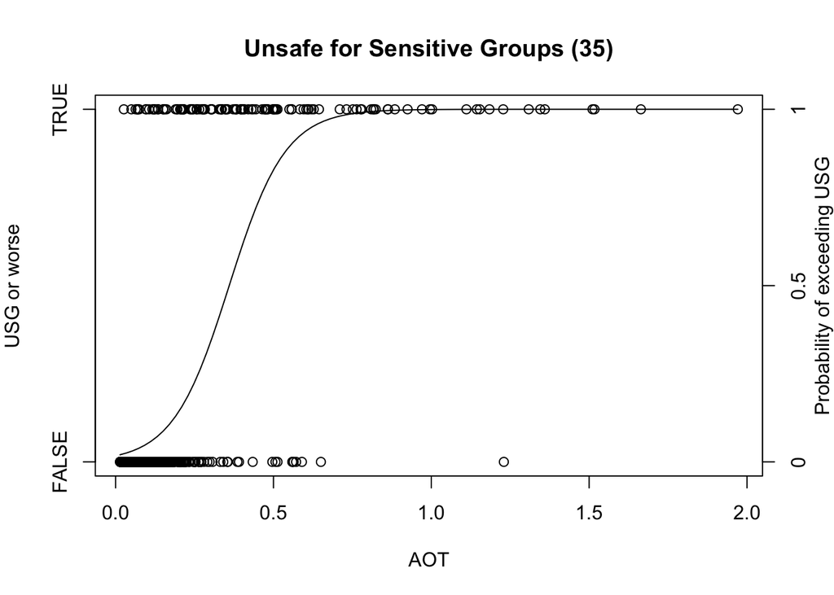

```r
plot(dfall$satellite, dfall$usg, xlab = "AOT", ylab = "USG or worse", yaxt = 'n', main = "Unsafe for Sensitive Groups (35)")
axis(2, at = c(0, 1), labels = c("FALSE", "TRUE"))
axis(4, at = c(0, .5,  1), labels = c("0", "0.5", "1"))
mtext("Probability of exceeding USG", 4, 2)
curve(exp(usgglm$coefficients[1] + usgglm$coefficients[2] * x)/(1 + exp(usgglm$coefficients[1] + usgglm$coefficients[2] * x)), add = TRUE)
```

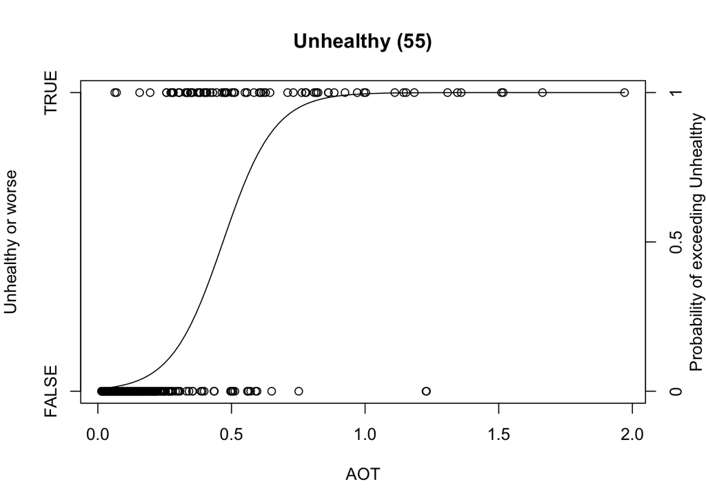

```r
plot(dfall$satellite, dfall$unhealthy, xlab = "AOT", ylab = "Unhealthy or worse", yaxt = 'n', main = "Unhealthy (55)")
axis(2, at = c(0, 1), labels = c("FALSE", "TRUE"))
axis(4, at = c(0, .5,  1), labels = c("0", "0.5", "1"))
mtext("Probability of exceeding Unhealthy", 4, 2)
curve(exp(unhealthyglm$coefficients[1] + unhealthyglm$coefficients[2] * x)/(1 + exp(unhealthyglm$coefficients[1] + unhealthyglm$coefficients[2] * x)), add = TRUE)
```

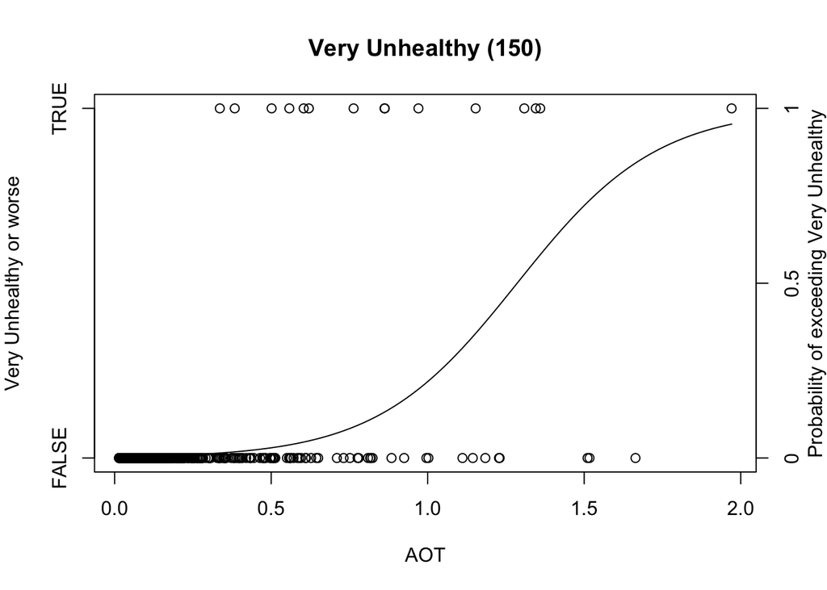

```r
plot(dfall$satellite, dfall$veryunhealthy, xlab = "AOT", ylab = "Very Unhealthy or worse", yaxt = 'n', main = "Very Unhealthy (150)")
axis(2, at = c(0, 1), labels = c("FALSE", "TRUE"))
axis(4, at = c(0, .5,  1), labels = c("0", "0.5", "1"))
mtext("Probability of exceeding Very Unhealthy", 4, 2)
curve(exp(veryunhealthyglm$coefficients[1] + veryunhealthyglm$coefficients[2] * x)/(1 + exp(veryunhealthyglm$coefficients[1] + veryunhealthyglm$coefficients[2] * x)), add = TRUE)
```

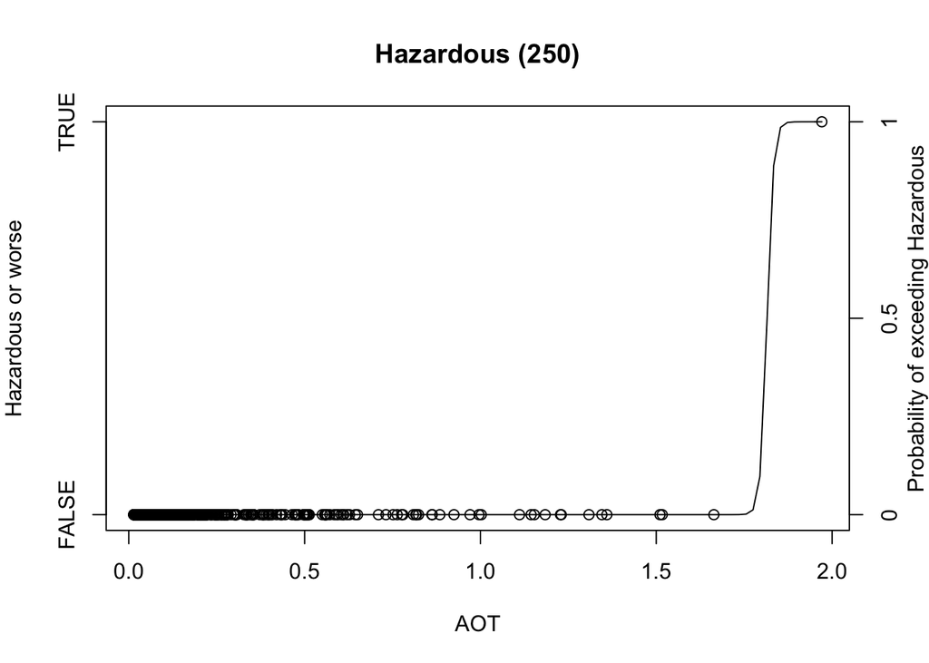

```r
plot(dfall$satellite, dfall$hazardous, xlab = "AOT", ylab = "Hazardous or worse", yaxt = 'n', main = "Hazardous (250)")
axis(2, at = c(0, 1), labels = c("FALSE", "TRUE"))
axis(4, at = c(0, .5,  1), labels = c("0", "0.5", "1"))
mtext("Probability of exceeding Hazardous", 4, 2)
curve(exp(hazardousglm$coefficients[1] + hazardousglm$coefficients[2] * x)/(1 + exp(hazardousglm$coefficients[1] + hazardousglm$coefficients[2] * x)), add = TRUE)
```

## Skill Metrics

Several skill meterics are reported here. The first is the confusion matrix for each threshold. It follows this form:

$$\begin{array}
{r|r|r|}
& \text{no} & \text{yes}\\\hline
\text{no} & \text{TN} & \text{FP} \\\hline
\text{yes} & \text{FN} & \text{TP} \\\hline
\end{array}$$

The skill metrics reported here are: #### Prevalence This is the proportion of observed values that were true. Calculated: (FN + TP)/total

### Accuracy This is the proportion of predictions that were correct. (TP + TN)/total

### True Positive Rate (TPR) This tells us how often the model was right out of all the true positives. TP/(TP + FN)

### False Positive Rate (FPR) This tells us how often the model was wrong when the actual value was False. FP/(FP + TN)

### Specificity (or True Negative Rate) This tells us how often the model was right when the true value is False. TN/(FP + TN)

```r
moderateskill <- skill_confusionMatrix(dfall$satellite > moderateThreshold, dfall$moderate)
usgskill <- skill_confusionMatrix(dfall$satellite > usgThreshold, dfall$usg)
unhealthyskill <- skill_confusionMatrix(dfall$satellite > unhealthyThreshold, dfall$unhealthy)
veryunhealthyskill <- skill_confusionMatrix(dfall$satellite > veryunhealthyThreshold, dfall$veryunhealthy)
hazardousskill <- skill_confusionMatrix(dfall$satellite > hazardousThreshold, dfall$hazardous)

moderateskill$table
```

```
##          Actual
## Predicted FALSE TRUE
##     FALSE   469  176
##     TRUE     44  188
```

```r
usgskill$table
```

```
##          Actual
## Predicted FALSE TRUE
##     FALSE   744   55
##     TRUE     13   65
```

```r
unhealthyskill$table
```

```
##          Actual
## Predicted FALSE TRUE
##     FALSE   782   34
##     TRUE     16   45
```

```r
veryunhealthyskill$table
```

```
##          Actual
## Predicted FALSE TRUE
##     FALSE   859   11
##     TRUE      3    4
```

```r
hazardousskill$table
```

```
##          Actual
## Predicted FALSE TRUE
##     FALSE   876    0
##     TRUE      0    1
```

```r
skillInfo <- data.frame(AQI = AQI$names[-1], PM25 = AQI$breaks_24[2:6], AOT = thresholds,
                        prevalence = c(moderateskill$prevalence, usgskill$prevalence, unhealthyskill$prevalence,
                                       veryunhealthyskill$prevalence, hazardousskill$prevalence),
                        accuracy = c(moderateskill$accuracy, usgskill$accuracy, unhealthyskill$accuracy,
                                     veryunhealthyskill$accuracy, hazardousskill$accuracy),
                        TPR = c(moderateskill$TPRate, usgskill$TPRate, unhealthyskill$TPRate,
                                veryunhealthyskill$TPRate, hazardousskill$TPRate),
                        FPR = c(moderateskill$FPRate, usgskill$FPRate, unhealthyskill$FPRate,
                                veryunhealthyskill$FPRate, hazardousskill$FPRate),
                        specificity = c(moderateskill$specificity, usgskill$specificity, unhealthyskill$specificity,
                                        veryunhealthyskill$specificity, hazardousskill$specificity),
                        precision = c(moderateskill$precision, usgskill$precision, unhealthyskill$precision,
                                      veryunhealthyskill$precision, veryunhealthyskill$precision))

knitr::kable(skillInfo)
```

| AQI | PM25 | AOT | prevalence | accuracy | TPR | FPR | specificity | precision |
| --- | --- | --- | --- | --- | --- | --- | --- | --- |
| Moderate | 12.0 | 0.1427335 | 0.4150513 | 0.7491448 | 0.5164835 | 0.0857700 | 0.9142300 | 0.8103448 |
| USG | 35.5 | 0.3599233 | 0.1368301 | 0.9224629 | 0.5416667 | 0.0171731 | 0.9828269 | 0.8333333 |
| Unhealthy | 55.5 | 0.4681644 | 0.0900798 | 0.9429875 | 0.5696203 | 0.0200501 | 0.9799499 | 0.7377049 |
| Very Unhealthy | 150.5 | 1.2858559 | 0.0171038 | 0.9840365 | 0.2666667 | 0.0034803 | 0.9965197 | 0.5714286 |
| Hazardous | 250.5 | 1.8150409 | 0.0011403 | 1.0000000 | 1.0000000 | 0.0000000 | 1.0000000 | 0.5714286 |

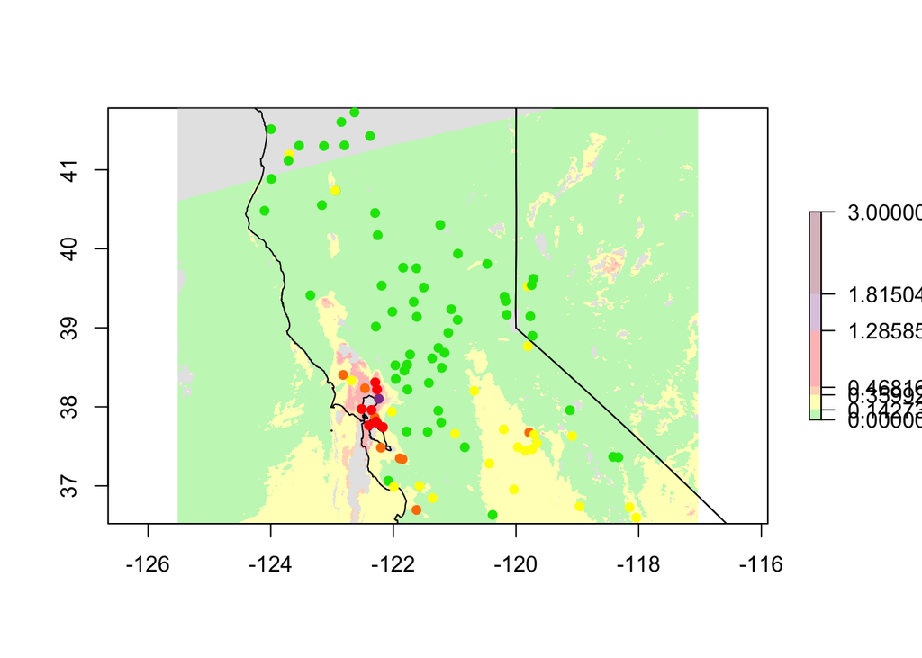

```r
plot(oct12A, breaks = c(0,thresholds, 3), col = adjustcolor(AQI$colors, alpha.f = .3), colNA = "gray90")
plot(USCensusStates, add = TRUE)
monitor_subset(fireMonitors, tlim = c(2017101221, 2017101222) ) %>%
    monitorMap(add = TRUE)
```

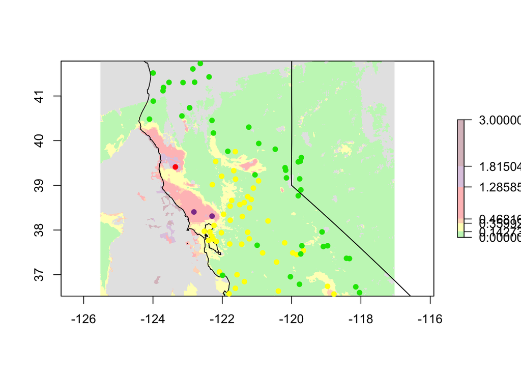

```r
plot(oct09A, breaks = c(0, thresholds, 3), col = adjustcolor(AQI$colors, alpha.f = .3), colNA = "gray90")
plot(USCensusStates, add = TRUE)
monitor_subset(fireMonitors, tlim = c(2017100921, 2017100922) ) %>%
    monitorMap(add = TRUE)
```

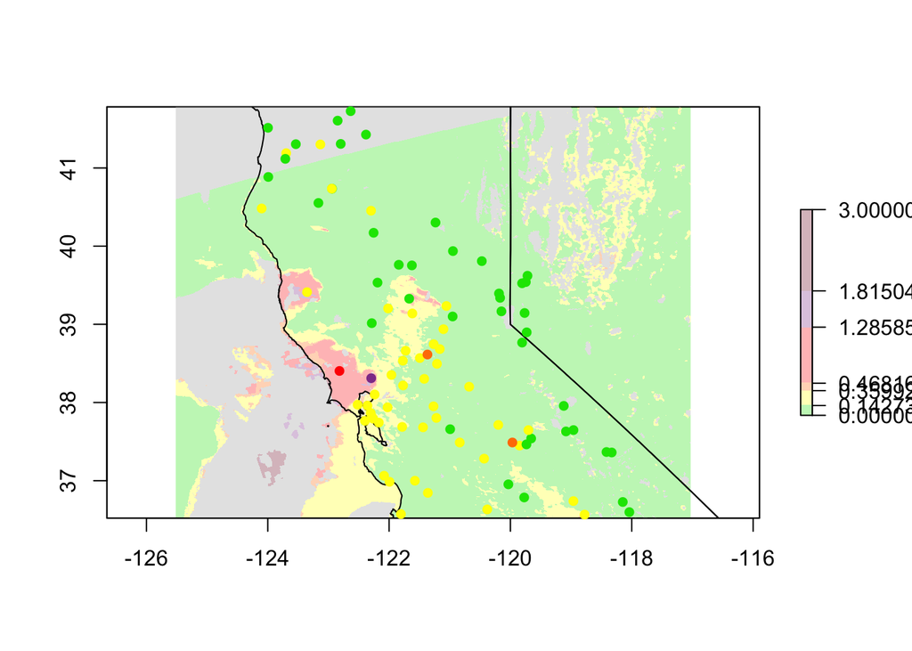

```r
plot(oct09T, breaks = c(0, thresholds, 3), col = adjustcolor(AQI$colors, alpha.f = .3), colNA = "gray90")
plot(USCensusStates, add = TRUE)
monitor_subset(fireMonitors, tlim = c(2017100919, 2017100920) ) %>%
    monitorMap(add = TRUE)
```